> This is a hypothetical paper written by two hypothetical individuals. It was prepared for presentation at the BITSS Summer Institute, June 2-6, 2014, to illustrate the TIER documentation protocol. www.haverford.edu/TIER

# Money, Happiness and the Midlife Crisis

## Ellsworth Dägg

## Lecturer in Economics and Horticulture

## Wallywell University

# and

## Picard Janné

## Director of Research

## Joint Economic and Statistical Taskforce

## June 3, 2014

## I. Introduction

This paper examines evidence from a multi-country survey of subjective well-being (SWB) to investigate two questions. The first is whether the survey shows evidence of the existence of a phenomenon that can be interpreted as a midlife crisis. The second is whether there is any evidence of an association between a country’s average SWB and each of two macro indicators, GPD per capita and government consumption expenditure. The policy relevance and intellectual significance of these questions has been verified by introspection. Trust us.[^1]  
The regression analysis of the survey data reported in this paper suggests that, across the lifespan, SWB follows the classic inverted U pattern, but turned upside down.[^2] The nature of the association we observe between country averages of SWB and GDP per capita depends heavily on one influential case, namely the US. When the US is included in the sample, one can argue for a positive association; if the US is excluded, there is weak evidence of a negative association. The association between SWB and government consumption appears to be negative, although the US is again an outlier. The evidence for the negative association becomes clearer when the US is excluded.

## II. Previous literature

This paper contributes to large and still growing literature that uses surveys of SWB to investigate a variety of socio-economic questions. The seminal work in this literature is Easterlin (1974), which focused on the association between SWB and various notions of income and socio-economic status. By one interpretation, Easterlin’s results suggest that we should expect to find little association between average income and average happiness in cross-sectional, country-level data. The pattern of SWB over the life cycle has been studied by Blanchflower and Oswald (2007), who find evidence of a U-shaped trajectory. They apparently fail to recognize, however, the deep resonance-of an anti-isomorphic nature-of the trajectory they observe with the classic inverse U pattern.

## IV. Descriptive statistics

Table 1 shows the values of CM_SATIS, GDP_PC and GOV_CONS for each of the seven countries in the sample.

Table 1: Mean Satisfaction, GPD per capita and Government Consumption by Country

| country.name | cm_satis | inc | exp |
| --- | --- | --- | --- |
| China | 5.174480 | 1135.4479 | 15.590028 |
| India | 5.085851 | 486.6405 | 11.890161 |
| Indonesia | 5.761539 | 909.8873 | 7.257458 |
| Jordan | 5.343716 | 1901.5804 | 22.695573 |
| Pakistan | 5.472683 | 483.0319 | 8.723921 |
| Russian Federation | 4.741266 | 2375.1579 | 17.953634 |
| United States | 7.019277 | 38175.3764 | 15.039799 |

## V. Analysis and results

If we use $\hat{\beta}_{AGE}$ to represent the estimated coefficient on *AGE* and $\hat{\beta}_{AGE-SQUARED}$ to represent the estimated coefficient on *AGE-SQUARED*, then the age of minimum SWB is equal to $-\frac{\hat{\beta}_{AGE}}{2\hat{\beta}_{AGE-SQUARED}}$. Using the estimated coefficients from our regressions we find:

Column 1 (no country fixed effects): Age at minimum SWB=47.76  
Column 2 (with country fixed effects): Age at minimum SWB=53.90

Depending on which specification we use, we find that the age at minimum *SWB* is about 47 years and 9 months or 53 years and 11 months. We interpret this pattern, in which estimated age at minimum SWB is within a few years of 50, as evidence in favor of a phenomenon that can be called a midlife crisis.

To examine the association between country means of SWB and GDP per capita, we construct the scatterplot shown in Figure 1. The OLS line through those points would probably be upward sloping, and maybe even statistically significant. However, such a result would be influenced heavily by the observation for the US. It appears that if the US were dropped from the sample, the association might in fact be negative.

## VI. Conclusion

The analysis presented in this paper provides evidence of an upside-down inverted U relationship between SWB and age, with minimum SWB occurring within a few years of 50. This result is consistent with the findings of Blanchflower and Oswald (2007). The country-level, cross-sectional associations between mean SWB and GDP per capita and between mean SWB and government consumption expenditures depend heavily on whether the US is included in the sample. 3 A careful analysis would include also things like robustness tests and other forms of sensitivity analysis, as well as consideration of the magnitude or practical significance of the estimated coefficients. To maintain the realism of this paper as an example of economic research, such considerations are omitted. 5

## References

Blanchflower, D. G., & Oswald, A. (2007). Is well-being U-shaped over the life cycle? National Bureau of Economic Research, Inc, NBER Working Papers: 12935. Easterlin, R. (1974.) “Does Economic Growth Improve the Human Lot? Some Empirical Evidence.” In Nations and Households in Economic Growth, ed. P. A. David and M. W. Reder. Stanford, CA: Stanford University Press.

## Sources of Data and Supporting Information

Pew Research Center Global Attitudes Project (2002a). SUMMER 2002 SURVEY DATA: 44- Nation Survey Conducted July 2-October 31, 2002 [Dataset]. Accessed at http://www.pewglobal.org/category/datasets/2002/, June 1, 2014. Pew Research Center Global Attitudes Project (2002b). SUMMER 2002 SURVEY DATA: 44- Nation Survey Conducted July 2-October 31, 2002 [Questionnaire]. Accessed at http://www.pewglobal.org/category/datasets/2002/, June 1, 2014. World Bank (2014). World Development Indicators On-line. Accessed at http://data.worldbank.org/data-catalog/world-development-indicators, June 1, 2014. 6

Notes:  
a) GPD per capita in current (2002) US dollars  
b) General government consumption expenditure, percent of GDP

**FIGURE 1**

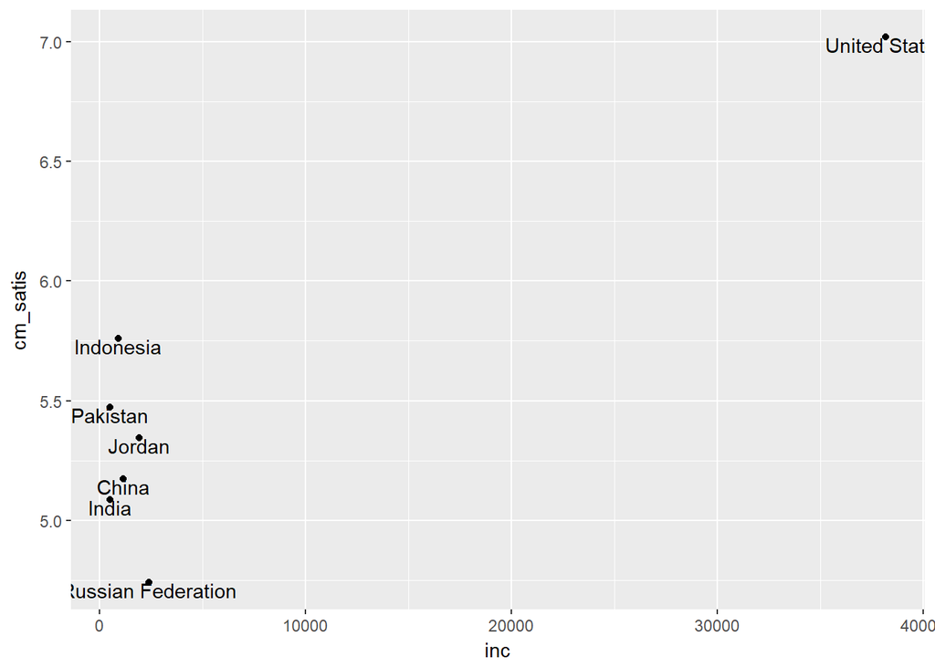

**FIGURE 2**

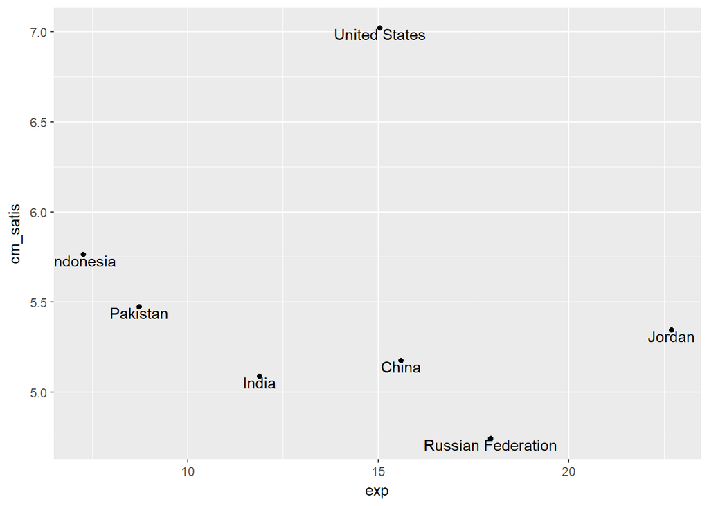